# Hidden Set MDS report 1-12-2017

```python
from IPython.display import Image, display, Latex

ball = 'ball_data_3000_vectors_3_to_2_dimensions.png'
sphere = 'sphere_data_1404_vectors_3_to_2_dimensions.png'
euclidean_spiral = 'euclidean_spiral_data_1404_vectors_3_to_2_dimensions.png'
geodesic_spiral = 'geodesic_spiral_data_1404_vectors_3_to_2_dimensions.png'
random_3000_10_3 = 'random_data_3000_vectors_10_to_3_dimensions.png'
random_500_100_10 = 'random_data_500_vectors_100_to_10_dimensions.png'

example_radius_gsd = 'rad_gsd.png'
example_radius_mds_v2 = 'rad_mds_v2.png'
big_radius = 'big_radius.png'
small_radius = 'small_radius.png'
```

## Current algorithm variation to GSD comparison

In GSD-MDS

- The iterations stop when error starts increasing
- Radius (step) is updated based on the continuous update rule \begin{equation} r_{i+1} = max(s, \frac{10s}{\sqrt{i + 1}}) \end{equation}
- In the old code $s=0.01$ (and generally $s$ takes small values)
- In each turn the points are sorted based on the error and a percentage of those points are pertubated

An example on how the radius changes for GSD and MDS-v2 is shown below

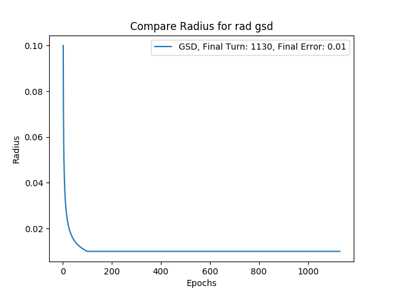

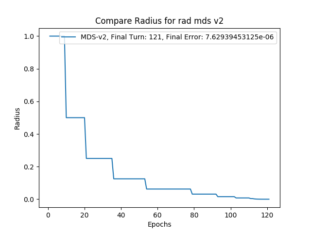

```python
display(Image(filename=example_radius_gsd))
display(Image(filename=example_radius_mds_v2))
```

```python
%%latex
\newpage
```

\newpage

## Results Comparison

### Points sampled inside ball

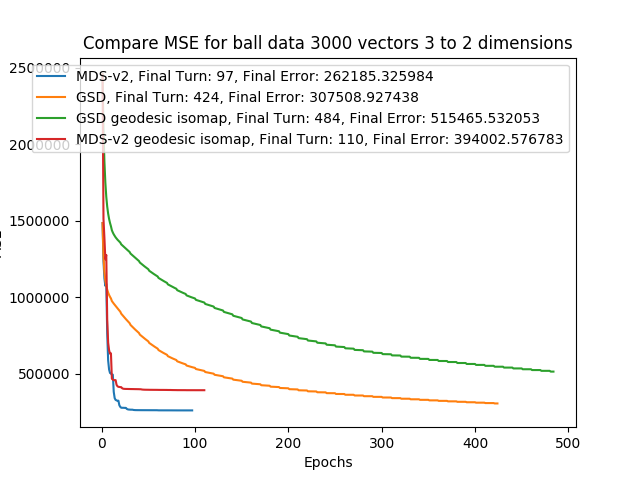

```python
display(Image(filename=ball))
```

```python
%%latex
\newpage
```

\newpage

### Points sampled on sphere surface

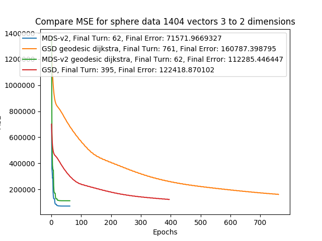

```python
display(Image(filename=sphere))
```

```python
%%latex
\newpage
```

\newpage

### Euclidean distances of points sampled on 3D spiral

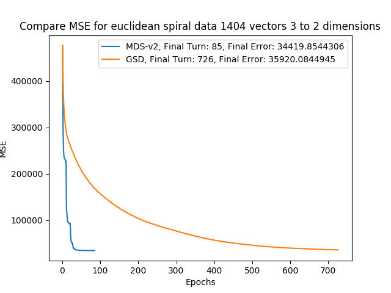

```python
display(Image(filename=euclidean_spiral))
```

```python
%%latex
\newpage
```

\newpage

### Geodesic distances of points sampled on 3D spiral

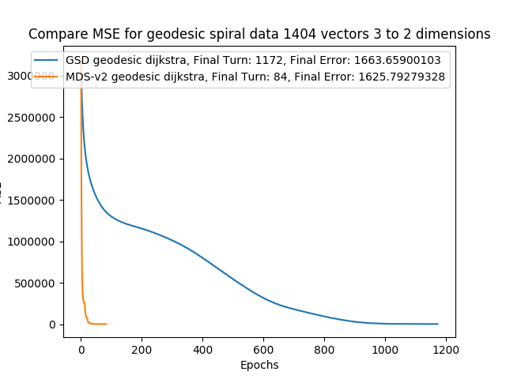

```python
display(Image(filename=geodesic_spiral))
```

```python
%%latex
\newpage
```

\newpage

### 3000 random points reduced from 10 to 3 dimensions

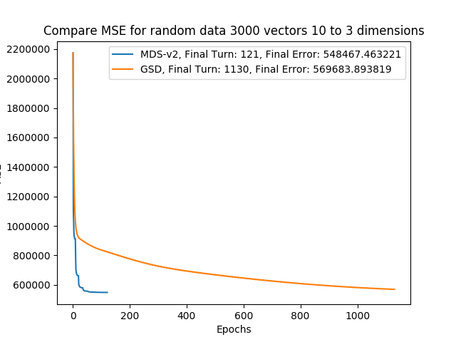

```python
display(Image(filename=random_3000_10_3))
```

```python
%%latex
\newpage
```

\newpage

### 500 random points reduced from 100 to 10 dimensions

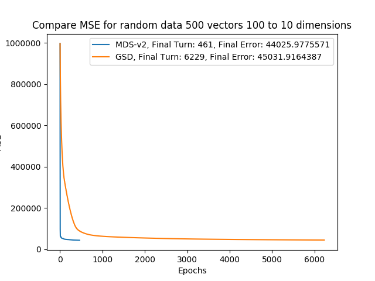

```python
display(Image(filename=random_500_100_10))
```

```python
%%latex
\newpage
```

\newpage

## Some interesting notes

Also MDS-v2 algorithm converges even if the starting radius is set to very high values.  
In the following experiment we set $r_0 = 100$.  
Notice the huge overshoot.

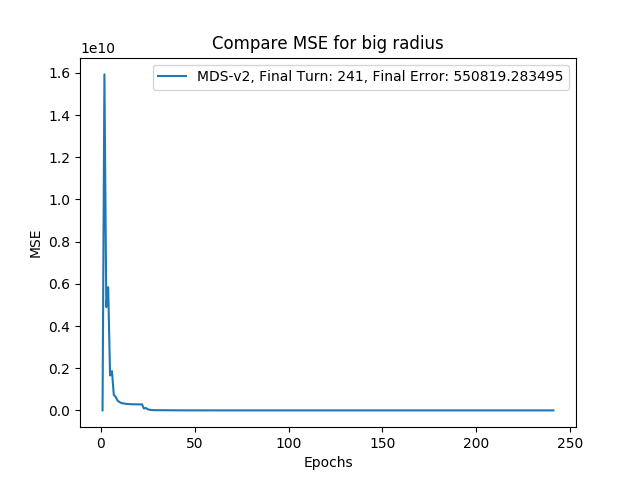

```python
display(Image(filename=big_radius))
```

```python
%%latex
\newpage
```

\newpage

Compare to the experiment run for $r_{0} = 1$

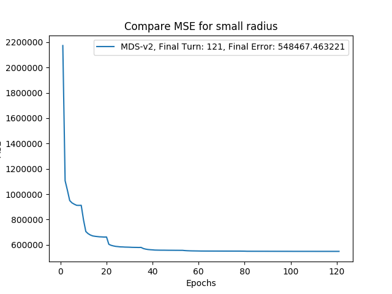

```python
display(Image(filename=small_radius))
```

## Questions

- The geodesic distance in the old code is calculated using Dijkstra. Is there a reason not to use the distances from Isomap?
- Any ideas for a better name than MDS-v2?
- Next steps?